# Risk Factor Analysis

## Outcome Variable

**Outcome Variable:** stunted

## Predictor Variables

**Intervention Variable:** month

**Adjustment Set:**

unadjusted

## Stratifying Variables

The analysis was stratified on these variable(s):

- agecat
- studyid
- country

## Data Summary

| agecat | studyid | country | month | stunted | n_cell | n |
| --- | --- | --- | --- | --- | --- | --- |
| Birth | ki0047075b-MAL-ED | BANGLADESH | 1 | 0 | 16 | 257 |
| Birth | ki0047075b-MAL-ED | BANGLADESH | 1 | 1 | 3 | 257 |
| Birth | ki0047075b-MAL-ED | BANGLADESH | 2 | 0 | 18 | 257 |
| Birth | ki0047075b-MAL-ED | BANGLADESH | 2 | 1 | 6 | 257 |
| Birth | ki0047075b-MAL-ED | BANGLADESH | 3 | 0 | 20 | 257 |
| Birth | ki0047075b-MAL-ED | BANGLADESH | 3 | 1 | 8 | 257 |
| Birth | ki0047075b-MAL-ED | BANGLADESH | 4 | 0 | 21 | 257 |
| Birth | ki0047075b-MAL-ED | BANGLADESH | 4 | 1 | 0 | 257 |
| Birth | ki0047075b-MAL-ED | BANGLADESH | 5 | 0 | 16 | 257 |
| Birth | ki0047075b-MAL-ED | BANGLADESH | 5 | 1 | 5 | 257 |
| Birth | ki0047075b-MAL-ED | BANGLADESH | 6 | 0 | 5 | 257 |
| Birth | ki0047075b-MAL-ED | BANGLADESH | 6 | 1 | 4 | 257 |
| Birth | ki0047075b-MAL-ED | BANGLADESH | 7 | 0 | 17 | 257 |
| Birth | ki0047075b-MAL-ED | BANGLADESH | 7 | 1 | 5 | 257 |
| Birth | ki0047075b-MAL-ED | BANGLADESH | 8 | 0 | 20 | 257 |
| Birth | ki0047075b-MAL-ED | BANGLADESH | 8 | 1 | 5 | 257 |
| Birth | ki0047075b-MAL-ED | BANGLADESH | 9 | 0 | 20 | 257 |
| Birth | ki0047075b-MAL-ED | BANGLADESH | 9 | 1 | 2 | 257 |
| Birth | ki0047075b-MAL-ED | BANGLADESH | 10 | 0 | 19 | 257 |
| Birth | ki0047075b-MAL-ED | BANGLADESH | 10 | 1 | 5 | 257 |
| Birth | ki0047075b-MAL-ED | BANGLADESH | 11 | 0 | 13 | 257 |
| Birth | ki0047075b-MAL-ED | BANGLADESH | 11 | 1 | 2 | 257 |
| Birth | ki0047075b-MAL-ED | BANGLADESH | 12 | 0 | 25 | 257 |
| Birth | ki0047075b-MAL-ED | BANGLADESH | 12 | 1 | 2 | 257 |
| 6 months | ki0047075b-MAL-ED | BANGLADESH | 1 | 0 | 13 | 241 |
| 6 months | ki0047075b-MAL-ED | BANGLADESH | 1 | 1 | 3 | 241 |
| 6 months | ki0047075b-MAL-ED | BANGLADESH | 2 | 0 | 14 | 241 |
| 6 months | ki0047075b-MAL-ED | BANGLADESH | 2 | 1 | 6 | 241 |
| 6 months | ki0047075b-MAL-ED | BANGLADESH | 3 | 0 | 20 | 241 |
| 6 months | ki0047075b-MAL-ED | BANGLADESH | 3 | 1 | 5 | 241 |

[output cut: 1473 more lines]

The following strata were considered:

- agecat: 24 months, studyid: ki0047075b-MAL-ED, country: BANGLADESH
- agecat: 24 months, studyid: ki0047075b-MAL-ED, country: BRAZIL
- agecat: 24 months, studyid: ki0047075b-MAL-ED, country: INDIA
- agecat: 24 months, studyid: ki0047075b-MAL-ED, country: NEPAL
- agecat: 24 months, studyid: ki0047075b-MAL-ED, country: PERU
- agecat: 24 months, studyid: ki0047075b-MAL-ED, country: SOUTH AFRICA
- agecat: 24 months, studyid: ki0047075b-MAL-ED, country: TANZANIA, UNITED REPUBLIC OF
- agecat: 24 months, studyid: ki1000108-CMC-V-BCS-2002, country: INDIA
- agecat: 24 months, studyid: ki1000108-IRC, country: INDIA
- agecat: 24 months, studyid: ki1017093-NIH-Birth, country: BANGLADESH
- agecat: 24 months, studyid: ki1066203-TanzaniaChild2, country: TANZANIA, UNITED REPUBLIC OF
- agecat: 24 months, studyid: ki1113344-GMS-Nepal, country: NEPAL
- agecat: 24 months, studyid: ki1114097-CMIN, country: BANGLADESH
- agecat: 24 months, studyid: ki1114097-CMIN, country: GUINEA-BISSAU
- agecat: 24 months, studyid: ki1114097-CMIN, country: PERU
- agecat: 24 months, studyid: ki1114097-CONTENT, country: PERU
- agecat: 24 months, studyid: ki1119695-PROBIT, country: BELARUS
- agecat: 24 months, studyid: ki1126311-ZVITAMBO, country: ZIMBABWE
- agecat: 24 months, studyid: ki1148112-LCNI-5, country: MALAWI
- agecat: 24 months, studyid: kiGH5241-JiVitA-3, country: BANGLADESH
- agecat: 24 months, studyid: kiGH5241-JiVitA-4, country: BANGLADESH
- agecat: 6 months, studyid: ki0047075b-MAL-ED, country: BANGLADESH
- agecat: 6 months, studyid: ki0047075b-MAL-ED, country: BRAZIL
- agecat: 6 months, studyid: ki0047075b-MAL-ED, country: INDIA
- agecat: 6 months, studyid: ki0047075b-MAL-ED, country: NEPAL
- agecat: 6 months, studyid: ki0047075b-MAL-ED, country: PERU
- agecat: 6 months, studyid: ki0047075b-MAL-ED, country: SOUTH AFRICA
- agecat: 6 months, studyid: ki0047075b-MAL-ED, country: TANZANIA, UNITED REPUBLIC OF
- agecat: 6 months, studyid: ki1000108-CMC-V-BCS-2002, country: INDIA
- agecat: 6 months, studyid: ki1000108-IRC, country: INDIA
- agecat: 6 months, studyid: ki1000109-EE, country: PAKISTAN
- agecat: 6 months, studyid: ki1000109-ResPak, country: PAKISTAN
- agecat: 6 months, studyid: ki1000304b-SAS-CompFeed, country: INDIA
- agecat: 6 months, studyid: ki1000304b-SAS-FoodSuppl, country: INDIA
- agecat: 6 months, studyid: ki1017093-NIH-Birth, country: BANGLADESH
- agecat: 6 months, studyid: ki1066203-TanzaniaChild2, country: TANZANIA, UNITED REPUBLIC OF
- agecat: 6 months, studyid: ki1112895-Guatemala BSC, country: GUATEMALA
- agecat: 6 months, studyid: ki1113344-GMS-Nepal, country: NEPAL
- agecat: 6 months, studyid: ki1114097-CMIN, country: BANGLADESH
- agecat: 6 months, studyid: ki1114097-CMIN, country: BRAZIL
- agecat: 6 months, studyid: ki1114097-CMIN, country: GUINEA-BISSAU
- agecat: 6 months, studyid: ki1114097-CMIN, country: PERU
- agecat: 6 months, studyid: ki1114097-CONTENT, country: PERU
- agecat: 6 months, studyid: ki1119695-PROBIT, country: BELARUS
- agecat: 6 months, studyid: ki1126311-ZVITAMBO, country: ZIMBABWE
- agecat: 6 months, studyid: ki1148112-LCNI-5, country: MALAWI
- agecat: 6 months, studyid: kiGH5241-JiVitA-3, country: BANGLADESH
- agecat: 6 months, studyid: kiGH5241-JiVitA-4, country: BANGLADESH
- agecat: Birth, studyid: ki0047075b-MAL-ED, country: BANGLADESH
- agecat: Birth, studyid: ki0047075b-MAL-ED, country: BRAZIL
- agecat: Birth, studyid: ki0047075b-MAL-ED, country: INDIA
- agecat: Birth, studyid: ki0047075b-MAL-ED, country: NEPAL
- agecat: Birth, studyid: ki0047075b-MAL-ED, country: PERU
- agecat: Birth, studyid: ki0047075b-MAL-ED, country: SOUTH AFRICA
- agecat: Birth, studyid: ki0047075b-MAL-ED, country: TANZANIA, UNITED REPUBLIC OF
- agecat: Birth, studyid: ki1000108-CMC-V-BCS-2002, country: INDIA
- agecat: Birth, studyid: ki1000108-IRC, country: INDIA
- agecat: Birth, studyid: ki1000109-EE, country: PAKISTAN
- agecat: Birth, studyid: ki1000109-ResPak, country: PAKISTAN
- agecat: Birth, studyid: ki1000304b-SAS-CompFeed, country: INDIA
- agecat: Birth, studyid: ki1017093-NIH-Birth, country: BANGLADESH
- agecat: Birth, studyid: ki1114097-CMIN, country: BANGLADESH
- agecat: Birth, studyid: ki1114097-CMIN, country: BRAZIL
- agecat: Birth, studyid: ki1114097-CMIN, country: PERU
- agecat: Birth, studyid: ki1114097-CONTENT, country: PERU
- agecat: Birth, studyid: ki1119695-PROBIT, country: BELARUS
- agecat: Birth, studyid: ki1126311-ZVITAMBO, country: ZIMBABWE
- agecat: Birth, studyid: kiGH5241-JiVitA-3, country: BANGLADESH
- agecat: Birth, studyid: kiGH5241-JiVitA-4, country: BANGLADESH

### Dropped Strata

Some strata were dropped due to rare outcomes:

- agecat: Birth, studyid: ki0047075b-MAL-ED, country: BANGLADESH
- agecat: 6 months, studyid: ki0047075b-MAL-ED, country: BANGLADESH
- agecat: 24 months, studyid: ki0047075b-MAL-ED, country: BANGLADESH
- agecat: Birth, studyid: ki0047075b-MAL-ED, country: BRAZIL
- agecat: 6 months, studyid: ki0047075b-MAL-ED, country: BRAZIL
- agecat: 24 months, studyid: ki0047075b-MAL-ED, country: BRAZIL
- agecat: Birth, studyid: ki0047075b-MAL-ED, country: INDIA
- agecat: 6 months, studyid: ki0047075b-MAL-ED, country: INDIA
- agecat: 24 months, studyid: ki0047075b-MAL-ED, country: INDIA
- agecat: 6 months, studyid: ki0047075b-MAL-ED, country: NEPAL
- agecat: 24 months, studyid: ki0047075b-MAL-ED, country: NEPAL
- agecat: Birth, studyid: ki0047075b-MAL-ED, country: NEPAL
- agecat: Birth, studyid: ki0047075b-MAL-ED, country: PERU
- agecat: 6 months, studyid: ki0047075b-MAL-ED, country: PERU
- agecat: 24 months, studyid: ki0047075b-MAL-ED, country: PERU
- agecat: Birth, studyid: ki0047075b-MAL-ED, country: SOUTH AFRICA
- agecat: 6 months, studyid: ki0047075b-MAL-ED, country: SOUTH AFRICA
- agecat: 24 months, studyid: ki0047075b-MAL-ED, country: SOUTH AFRICA
- agecat: Birth, studyid: ki0047075b-MAL-ED, country: TANZANIA, UNITED REPUBLIC OF
- agecat: 6 months, studyid: ki0047075b-MAL-ED, country: TANZANIA, UNITED REPUBLIC OF
- agecat: 24 months, studyid: ki0047075b-MAL-ED, country: TANZANIA, UNITED REPUBLIC OF
- agecat: 24 months, studyid: ki1000108-CMC-V-BCS-2002, country: INDIA
- agecat: Birth, studyid: ki1000108-CMC-V-BCS-2002, country: INDIA
- agecat: 24 months, studyid: ki1000108-IRC, country: INDIA
- agecat: Birth, studyid: ki1000108-IRC, country: INDIA
- agecat: 6 months, studyid: ki1000109-EE, country: PAKISTAN
- agecat: Birth, studyid: ki1000109-EE, country: PAKISTAN
- agecat: Birth, studyid: ki1000109-ResPak, country: PAKISTAN
- agecat: 6 months, studyid: ki1000109-ResPak, country: PAKISTAN
- agecat: Birth, studyid: ki1000304b-SAS-CompFeed, country: INDIA
- agecat: Birth, studyid: ki1017093-NIH-Birth, country: BANGLADESH
- agecat: 24 months, studyid: ki1066203-TanzaniaChild2, country: TANZANIA, UNITED REPUBLIC OF
- agecat: 6 months, studyid: ki1112895-Guatemala BSC, country: GUATEMALA
- agecat: 6 months, studyid: ki1113344-GMS-Nepal, country: NEPAL
- agecat: 24 months, studyid: ki1113344-GMS-Nepal, country: NEPAL
- agecat: 6 months, studyid: ki1114097-CMIN, country: BANGLADESH
- agecat: 24 months, studyid: ki1114097-CMIN, country: BANGLADESH
- agecat: Birth, studyid: ki1114097-CMIN, country: BANGLADESH
- agecat: Birth, studyid: ki1114097-CMIN, country: BRAZIL
- agecat: 6 months, studyid: ki1114097-CMIN, country: BRAZIL
- agecat: 6 months, studyid: ki1114097-CMIN, country: GUINEA-BISSAU
- agecat: 6 months, studyid: ki1114097-CMIN, country: PERU
- agecat: 24 months, studyid: ki1114097-CMIN, country: PERU
- agecat: Birth, studyid: ki1114097-CMIN, country: PERU
- agecat: 6 months, studyid: ki1114097-CONTENT, country: PERU
- agecat: 24 months, studyid: ki1114097-CONTENT, country: PERU
- agecat: Birth, studyid: ki1114097-CONTENT, country: PERU
- agecat: Birth, studyid: ki1119695-PROBIT, country: BELARUS
- agecat: 24 months, studyid: ki1126311-ZVITAMBO, country: ZIMBABWE
- agecat: Birth, studyid: kiGH5241-JiVitA-4, country: BANGLADESH

## Methods Detail

We’re interested in the causal parameters $E[Y_a]$ for all values of $a \in \mathcal{A}$. These parameters represent the mean outcome if, possibly contrary to fact, we intervened to set all units to have $A=a$. Under the randomization and positivity assumptions, these are identified by the statistical parameters $\psi_a=E_W[E_{Y|A,W}(Y|A=a,W)]$. In addition, we’re interested in the mean of $Y$, $E[Y]$ under no intervention (the observed mean). We will estimate these parameters by using SuperLearner to fit the relevant likelihood factors – $E_{Y|A,W}(Y|A=a,W)$ and $p(A=a|W)$, and then updating our likelihood fit using a joint TMLE.

For unadjusted analyses ($W=\{\}$), initial likelihoods were estimated using Lrnr_glm to estimate the simple $E(Y|A)$ and Lrnr_mean to estimate $p(A)$. For adjusted analyses, a small library containing Lrnr_glmnet, Lrnr_xgboost, and Lrnr_mean was used.

Having estimated these parameters, we will then use the delta method to estimate relative risks and attributable risks relative to a prespecified baseline level of $A$.

# Results Detail

## Results Plots

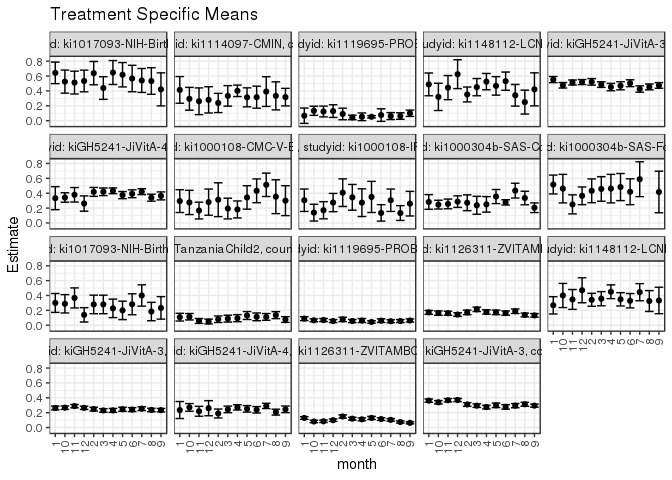

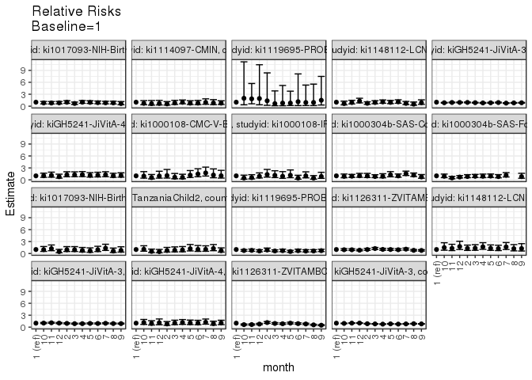

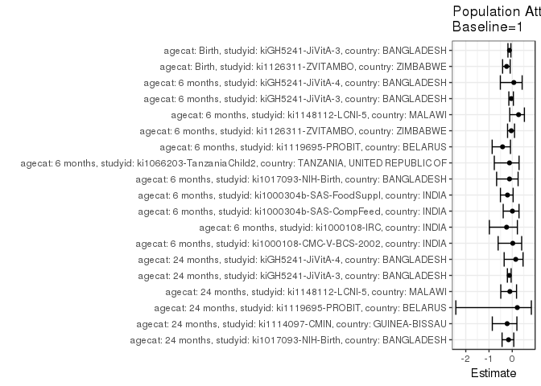

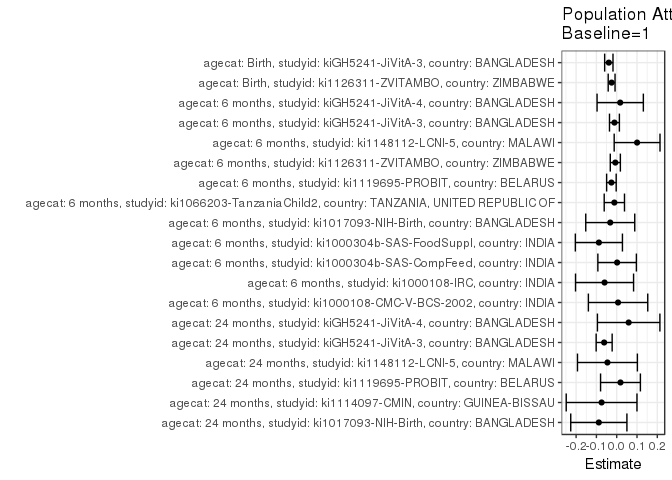

## Results Table

### Parameter: TSM

| agecat | studyid | country | intervention_level | baseline_level | estimate | ci_lower | ci_upper |
| --- | --- | --- | --- | --- | --- | --- | --- |
| Birth | ki1126311-ZVITAMBO | ZIMBABWE | 1 | NA | 0.1287202 | 0.1108156 | 0.1466249 |
| Birth | ki1126311-ZVITAMBO | ZIMBABWE | 2 | NA | 0.1486486 | 0.1269856 | 0.1703117 |
| Birth | ki1126311-ZVITAMBO | ZIMBABWE | 3 | NA | 0.1192982 | 0.1004816 | 0.1381149 |
| Birth | ki1126311-ZVITAMBO | ZIMBABWE | 4 | NA | 0.1102284 | 0.0908849 | 0.1295719 |
| Birth | ki1126311-ZVITAMBO | ZIMBABWE | 5 | NA | 0.1290000 | 0.1082237 | 0.1497763 |
| Birth | ki1126311-ZVITAMBO | ZIMBABWE | 6 | NA | 0.1139576 | 0.0954462 | 0.1324690 |
| Birth | ki1126311-ZVITAMBO | ZIMBABWE | 7 | NA | 0.1028912 | 0.0855263 | 0.1202560 |
| Birth | ki1126311-ZVITAMBO | ZIMBABWE | 8 | NA | 0.0742251 | 0.0595512 | 0.0888991 |
| Birth | ki1126311-ZVITAMBO | ZIMBABWE | 9 | NA | 0.0632140 | 0.0500509 | 0.0763771 |
| Birth | ki1126311-ZVITAMBO | ZIMBABWE | 10 | NA | 0.0815739 | 0.0649540 | 0.0981938 |
| Birth | ki1126311-ZVITAMBO | ZIMBABWE | 11 | NA | 0.0837743 | 0.0676487 | 0.0998998 |
| Birth | ki1126311-ZVITAMBO | ZIMBABWE | 12 | NA | 0.0988048 | 0.0822950 | 0.1153145 |
| Birth | kiGH5241-JiVitA-3 | BANGLADESH | 1 | NA | 0.3619502 | 0.3401238 | 0.3837766 |
| Birth | kiGH5241-JiVitA-3 | BANGLADESH | 2 | NA | 0.3101023 | 0.2850990 | 0.3351056 |
| Birth | kiGH5241-JiVitA-3 | BANGLADESH | 3 | NA | 0.2941805 | 0.2705802 | 0.3177807 |
| Birth | kiGH5241-JiVitA-3 | BANGLADESH | 4 | NA | 0.2749267 | 0.2499835 | 0.2998698 |
| Birth | kiGH5241-JiVitA-3 | BANGLADESH | 5 | NA | 0.2986472 | 0.2681570 | 0.3291375 |
| Birth | kiGH5241-JiVitA-3 | BANGLADESH | 6 | NA | 0.2779456 | 0.2473758 | 0.3085155 |
| Birth | kiGH5241-JiVitA-3 | BANGLADESH | 7 | NA | 0.2946593 | 0.2664352 | 0.3228834 |
| Birth | kiGH5241-JiVitA-3 | BANGLADESH | 8 | NA | 0.3130435 | 0.2870085 | 0.3390784 |
| Birth | kiGH5241-JiVitA-3 | BANGLADESH | 9 | NA | 0.2945903 | 0.2741450 | 0.3150355 |
| Birth | kiGH5241-JiVitA-3 | BANGLADESH | 10 | NA | 0.3400848 | 0.3173098 | 0.3628598 |
| Birth | kiGH5241-JiVitA-3 | BANGLADESH | 11 | NA | 0.3668203 | 0.3442300 | 0.3894105 |
| Birth | kiGH5241-JiVitA-3 | BANGLADESH | 12 | NA | 0.3699552 | 0.3482745 | 0.3916358 |
| 6 months | ki1000108-CMC-V-BCS-2002 | INDIA | 1 | NA | 0.2941176 | 0.1407532 | 0.4474821 |
| 6 months | ki1000108-CMC-V-BCS-2002 | INDIA | 2 | NA | 0.3125000 | 0.0850747 | 0.5399253 |
| 6 months | ki1000108-CMC-V-BCS-2002 | INDIA | 3 | NA | 0.1935484 | 0.0542839 | 0.3328129 |
| 6 months | ki1000108-CMC-V-BCS-2002 | INDIA | 4 | NA | 0.1818182 | 0.0677001 | 0.2959363 |
| 6 months | ki1000108-CMC-V-BCS-2002 | INDIA | 5 | NA | 0.3428571 | 0.1853900 | 0.5003242 |
| 6 months | ki1000108-CMC-V-BCS-2002 | INDIA | 6 | NA | 0.4324324 | 0.2725855 | 0.5922794 |

[output cut: 197 more lines]

### Parameter: E(Y)

| agecat | studyid | country | intervention_level | baseline_level | estimate | ci_lower | ci_upper |
| --- | --- | --- | --- | --- | --- | --- | --- |
| Birth | ki1126311-ZVITAMBO | ZIMBABWE | NA | NA | 0.1036581 | 0.0985732 | 0.1087430 |
| Birth | kiGH5241-JiVitA-3 | BANGLADESH | NA | NA | 0.3231530 | 0.3154984 | 0.3308077 |
| 6 months | ki1000108-CMC-V-BCS-2002 | INDIA | NA | NA | 0.3008130 | 0.2539566 | 0.3476694 |
| 6 months | ki1000108-IRC | INDIA | NA | NA | 0.2457002 | 0.2038248 | 0.2875757 |
| 6 months | ki1000304b-SAS-CompFeed | INDIA | NA | NA | 0.2844311 | 0.2666491 | 0.3022132 |
| 6 months | ki1000304b-SAS-FoodSuppl | INDIA | NA | NA | 0.4289474 | 0.3791199 | 0.4787748 |
| 6 months | ki1017093-NIH-Birth | BANGLADESH | NA | NA | 0.2681564 | 0.2306532 | 0.3056597 |
| 6 months | ki1066203-TanzaniaChild2 | TANZANIA, UNITED REPUBLIC OF | NA | NA | 0.0970922 | 0.0842059 | 0.1099785 |
| 6 months | ki1119695-PROBIT | BELARUS | NA | NA | 0.0626864 | 0.0488489 | 0.0765239 |
| 6 months | ki1126311-ZVITAMBO | ZIMBABWE | NA | NA | 0.1660829 | 0.1580659 | 0.1740998 |
| 6 months | ki1148112-LCNI-5 | MALAWI | NA | NA | 0.3682956 | 0.3356382 | 0.4009530 |
| 6 months | kiGH5241-JiVitA-3 | BANGLADESH | NA | NA | 0.2513830 | 0.2432594 | 0.2595066 |
| 6 months | kiGH5241-JiVitA-4 | BANGLADESH | NA | NA | 0.2525357 | 0.2384780 | 0.2665934 |
| 24 months | ki1017093-NIH-Birth | BANGLADESH | NA | NA | 0.5547786 | 0.5076945 | 0.6018626 |
| 24 months | ki1114097-CMIN | GUINEA-BISSAU | NA | NA | 0.3393829 | 0.2998111 | 0.3789548 |
| 24 months | ki1119695-PROBIT | BELARUS | NA | NA | 0.0852540 | 0.0554439 | 0.1150642 |
| 24 months | ki1148112-LCNI-5 | MALAWI | NA | NA | 0.4421416 | 0.4016536 | 0.4826297 |
| 24 months | kiGH5241-JiVitA-3 | BANGLADESH | NA | NA | 0.4907322 | 0.4775988 | 0.5038655 |
| 24 months | kiGH5241-JiVitA-4 | BANGLADESH | NA | NA | 0.3922559 | 0.3752678 | 0.4092440 |

### Parameter: RR

| agecat | studyid | country | intervention_level | baseline_level | estimate | ci_lower | ci_upper |
| --- | --- | --- | --- | --- | --- | --- | --- |
| Birth | ki1126311-ZVITAMBO | ZIMBABWE | 1 | 1 | 1.0000000 | 1.0000000 | 1.0000000 |
| Birth | ki1126311-ZVITAMBO | ZIMBABWE | 2 | 1 | 1.1548196 | 0.9441066 | 1.4125610 |
| Birth | ki1126311-ZVITAMBO | ZIMBABWE | 3 | 1 | 0.9268026 | 0.7510259 | 1.1437195 |
| Birth | ki1126311-ZVITAMBO | ZIMBABWE | 4 | 1 | 0.8563409 | 0.6845361 | 1.0712652 |
| Birth | ki1126311-ZVITAMBO | ZIMBABWE | 5 | 1 | 1.0021734 | 0.8100680 | 1.2398361 |
| Birth | ki1126311-ZVITAMBO | ZIMBABWE | 6 | 1 | 0.8853122 | 0.7148568 | 1.0964121 |
| Birth | ki1126311-ZVITAMBO | ZIMBABWE | 7 | 1 | 0.7993394 | 0.6423171 | 0.9947477 |
| Birth | ki1126311-ZVITAMBO | ZIMBABWE | 8 | 1 | 0.5766391 | 0.4528181 | 0.7343183 |
| Birth | ki1126311-ZVITAMBO | ZIMBABWE | 9 | 1 | 0.4910962 | 0.3823070 | 0.6308424 |
| Birth | ki1126311-ZVITAMBO | ZIMBABWE | 10 | 1 | 0.6337302 | 0.4951837 | 0.8110403 |
| Birth | ki1126311-ZVITAMBO | ZIMBABWE | 11 | 1 | 0.6508242 | 0.5132450 | 0.8252826 |
| Birth | ki1126311-ZVITAMBO | ZIMBABWE | 12 | 1 | 0.7675932 | 0.6176032 | 0.9540095 |
| Birth | kiGH5241-JiVitA-3 | BANGLADESH | 1 | 1 | 1.0000000 | 1.0000000 | 1.0000000 |
| Birth | kiGH5241-JiVitA-3 | BANGLADESH | 2 | 1 | 0.8567541 | 0.7709215 | 0.9521431 |
| Birth | kiGH5241-JiVitA-3 | BANGLADESH | 3 | 1 | 0.8127650 | 0.7361268 | 0.8973821 |
| Birth | kiGH5241-JiVitA-3 | BANGLADESH | 4 | 1 | 0.7595705 | 0.6815759 | 0.8464903 |
| Birth | kiGH5241-JiVitA-3 | BANGLADESH | 5 | 1 | 0.8251059 | 0.7325773 | 0.9293214 |
| Birth | kiGH5241-JiVitA-3 | BANGLADESH | 6 | 1 | 0.7679112 | 0.6786541 | 0.8689076 |
| Birth | kiGH5241-JiVitA-3 | BANGLADESH | 7 | 1 | 0.8140880 | 0.7294587 | 0.9085357 |
| Birth | kiGH5241-JiVitA-3 | BANGLADESH | 8 | 1 | 0.8648800 | 0.7797751 | 0.9592733 |
| Birth | kiGH5241-JiVitA-3 | BANGLADESH | 9 | 1 | 0.8138972 | 0.7447011 | 0.8895229 |
| Birth | kiGH5241-JiVitA-3 | BANGLADESH | 10 | 1 | 0.9395900 | 0.8600901 | 1.0264383 |
| Birth | kiGH5241-JiVitA-3 | BANGLADESH | 11 | 1 | 1.0134551 | 0.9339407 | 1.0997394 |
| Birth | kiGH5241-JiVitA-3 | BANGLADESH | 12 | 1 | 1.0221162 | 0.9411024 | 1.1101041 |
| 6 months | ki1000108-CMC-V-BCS-2002 | INDIA | 1 | 1 | 1.0000000 | 1.0000000 | 1.0000000 |
| 6 months | ki1000108-CMC-V-BCS-2002 | INDIA | 2 | 1 | 1.0625000 | 0.4340220 | 2.6010345 |
| 6 months | ki1000108-CMC-V-BCS-2002 | INDIA | 3 | 1 | 0.6580645 | 0.2706140 | 1.6002457 |
| 6 months | ki1000108-CMC-V-BCS-2002 | INDIA | 4 | 1 | 0.6181818 | 0.2733603 | 1.3979672 |
| 6 months | ki1000108-CMC-V-BCS-2002 | INDIA | 5 | 1 | 1.1657143 | 0.5818574 | 2.3354345 |
| 6 months | ki1000108-CMC-V-BCS-2002 | INDIA | 6 | 1 | 1.4702703 | 0.7759069 | 2.7860231 |

[output cut: 197 more lines]

### Parameter: PAR

| agecat | studyid | country | intervention_level | baseline_level | estimate | ci_lower | ci_upper |
| --- | --- | --- | --- | --- | --- | --- | --- |
| Birth | ki1126311-ZVITAMBO | ZIMBABWE | 1 | NA | -0.0250621 | -0.0419148 | -0.0082094 |
| Birth | kiGH5241-JiVitA-3 | BANGLADESH | 1 | NA | -0.0387972 | -0.0592872 | -0.0183071 |
| 6 months | ki1000108-CMC-V-BCS-2002 | INDIA | 1 | NA | 0.0066954 | -0.1395296 | 0.1529203 |
| 6 months | ki1000108-IRC | INDIA | 1 | NA | -0.0598553 | -0.2028108 | 0.0831002 |
| 6 months | ki1000304b-SAS-CompFeed | INDIA | 1 | NA | 0.0020782 | -0.0928369 | 0.0969933 |
| 6 months | ki1000304b-SAS-FoodSuppl | INDIA | 1 | NA | -0.0877193 | -0.2036977 | 0.0282591 |
| 6 months | ki1017093-NIH-Birth | BANGLADESH | 1 | NA | -0.0318436 | -0.1525110 | 0.0888238 |
| 6 months | ki1066203-TanzaniaChild2 | TANZANIA, UNITED REPUBLIC OF | 1 | NA | -0.0116035 | -0.0615755 | 0.0383685 |
| 6 months | ki1119695-PROBIT | BELARUS | 1 | NA | -0.0261360 | -0.0496775 | -0.0025944 |
| 6 months | ki1126311-ZVITAMBO | ZIMBABWE | 1 | NA | -0.0068027 | -0.0315992 | 0.0179937 |
| 6 months | ki1148112-LCNI-5 | MALAWI | 1 | NA | 0.1004384 | -0.0124209 | 0.2132978 |
| 6 months | kiGH5241-JiVitA-3 | BANGLADESH | 1 | NA | -0.0111539 | -0.0355223 | 0.0132146 |
| 6 months | kiGH5241-JiVitA-4 | BANGLADESH | 1 | NA | 0.0172416 | -0.0967783 | 0.1312615 |
| 24 months | ki1017093-NIH-Birth | BANGLADESH | 1 | NA | -0.0880786 | -0.2264399 | 0.0502827 |
| 24 months | ki1114097-CMIN | GUINEA-BISSAU | 1 | NA | -0.0744102 | -0.2486730 | 0.0998527 |
| 24 months | ki1119695-PROBIT | BELARUS | 1 | NA | 0.0185874 | -0.0795150 | 0.1166897 |
| 24 months | ki1148112-LCNI-5 | MALAWI | 1 | NA | -0.0456633 | -0.1932041 | 0.1018776 |
| 24 months | kiGH5241-JiVitA-3 | BANGLADESH | 1 | NA | -0.0618247 | -0.1012132 | -0.0224361 |
| 24 months | kiGH5241-JiVitA-4 | BANGLADESH | 1 | NA | 0.0589226 | -0.0949467 | 0.2127918 |

### Parameter: PAF

| agecat | studyid | country | intervention_level | baseline_level | estimate | ci_lower | ci_upper |
| --- | --- | --- | --- | --- | --- | --- | --- |
| Birth | ki1126311-ZVITAMBO | ZIMBABWE | 1 | NA | -0.2417770 | -0.4151278 | -0.0896613 |
| Birth | kiGH5241-JiVitA-3 | BANGLADESH | 1 | NA | -0.1200582 | -0.1853810 | -0.0583352 |
| 6 months | ki1000108-CMC-V-BCS-2002 | INDIA | 1 | NA | 0.0222576 | -0.6074578 | 0.4052843 |
| 6 months | ki1000108-IRC | INDIA | 1 | NA | -0.2436111 | -0.9850568 | 0.2208946 |
| 6 months | ki1000304b-SAS-CompFeed | INDIA | 1 | NA | 0.0073065 | -0.3894149 | 0.2907516 |
| 6 months | ki1000304b-SAS-FoodSuppl | INDIA | 1 | NA | -0.2044990 | -0.5086849 | 0.0383560 |
| 6 months | ki1017093-NIH-Birth | BANGLADESH | 1 | NA | -0.1187500 | -0.6726134 | 0.2517090 |
| 6 months | ki1066203-TanzaniaChild2 | TANZANIA, UNITED REPUBLIC OF | 1 | NA | -0.1195100 | -0.7726362 | 0.2929724 |
| 6 months | ki1119695-PROBIT | BELARUS | 1 | NA | -0.4169323 | -0.8641808 | -0.0769863 |
| 6 months | ki1126311-ZVITAMBO | ZIMBABWE | 1 | NA | -0.0409597 | -0.2014903 | 0.0981224 |
| 6 months | ki1148112-LCNI-5 | MALAWI | 1 | NA | 0.2727115 | -0.1081699 | 0.5226828 |
| 6 months | kiGH5241-JiVitA-3 | BANGLADESH | 1 | NA | -0.0443699 | -0.1459951 | 0.0482432 |
| 6 months | kiGH5241-JiVitA-4 | BANGLADESH | 1 | NA | 0.0682739 | -0.5124200 | 0.4260102 |
| 24 months | ki1017093-NIH-Birth | BANGLADESH | 1 | NA | -0.1587635 | -0.4378866 | 0.0661761 |
| 24 months | ki1114097-CMIN | GUINEA-BISSAU | 1 | NA | -0.2192513 | -0.8580064 | 0.1999092 |
| 24 months | ki1119695-PROBIT | BELARUS | 1 | NA | 0.2180233 | -2.4272927 | 0.8215829 |
| 24 months | ki1148112-LCNI-5 | MALAWI | 1 | NA | -0.1032774 | -0.4930707 | 0.1847532 |
| 24 months | kiGH5241-JiVitA-3 | BANGLADESH | 1 | NA | -0.1259845 | -0.2093771 | -0.0483423 |
| 24 months | kiGH5241-JiVitA-4 | BANGLADESH | 1 | NA | 0.1502146 | -0.3482913 | 0.4644071 |